# k-Means Mon Dec 16 24, 14:24:24

**Number of clusters:** 2  
**Optimization:** initialize with KMeans++, 1 re-runs limited to 10000 steps

## Data

**Data instances:** 359  
**Features:** FS Lin mom_1, FS Lin mom_2, FS Lin mom_3, FS Lin mom_4, SS Log mom_1, SS Log mom_2, SS Log mom_3, SS Log mom_4, CD13-PE mom_1, CD13-PE mom_2, CD13-PE mom_3, CD13-PE mom_4, IgG1-PE mom_1, IgG1-PE mom_2, IgG1-PE mom_3, IgG1-PE mom_4, CD11c-PE mom_1, CD11c-PE mom_2, CD11c-PE mom_3, CD11c-PE mom_4, CD4-PE mom_1, CD4-PE mom_2, CD4-PE mom_3, CD4-PE mom_4, CD15-FITC mom_1, CD15-FITC mom_2, CD15-FITC mom_3, CD15-FITC mom_4, CD10-PC7 mom_1, CD10-PC7 mom_2, CD10-PC7 mom_3, CD10-PC7 mom_4, CD34-PC5 mom_1, CD34-PC5 mom_2, CD34-PC5 mom_3, CD34-PC5 mom_4, CD3-PC5 mom_1, CD3-PC5 mom_2, CD3-PC5 mom_3, CD3-PC5 mom_4, CD14-FITC mom_1, CD14-FITC mom_2, CD14-FITC mom_3, CD14-FITC mom_4, Lambda-PE mom_1, Lambda-PE mom_2, Lambda-PE mom_3, Lambda-PE mom_4, CD20-PC7 mom_1, CD20-PC7 mom_2, CD20-PC7 mom_3, CD20-PC7 mom_4, CD19-PE mom_1, CD19-PE mom_2, CD19-PE mom_3, CD19-PE mom_4, CD64-PC5 mom_1, CD64-PC5 mom_2, CD64-PC5 mom_3, CD64-PC5 mom_4, CD8-PC5 mom_1, CD8-PC5 mom_2, CD8-PC5 mom_3, CD8-PC5 mom_4, ... (total: 128 features)  
**Meta attributes:** class

## Silhouette scores for different numbers of clusters

| 2 | 0.157 |
| --- | --- |
| 3 | 0.080 |
| 4 | 0.076 |

# Scatter Plot Mon Dec 16 24, 14:25:38

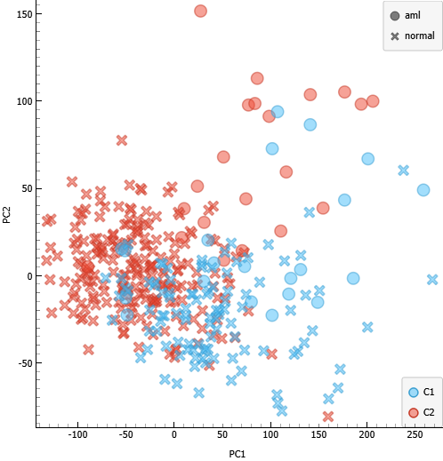

**Color**: Cluster, **Shape**: class

# Scatter Plot Mon Dec 16 24, 14:29:41

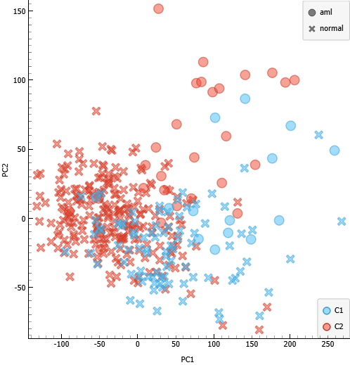

**Color**: Cluster, **Shape**: class

# t-SNE Mon Dec 16 24, 14:30:37

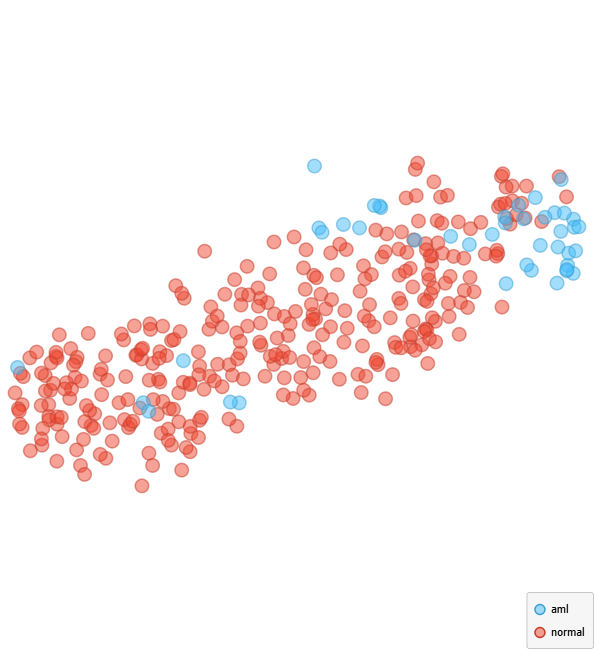

**Color**: class

# Test and Score Mon Dec 16 24, 18:29:58

## Settings

**Sampling type:** Stratified 10-fold Cross validation  
**Target class:** aml

## Scores

| Model | AUC | CA | F1 | Prec | Recall | Spec |
| --- | --- | --- | --- | --- | --- | --- |
| SVM | 0.997 | 0.992 | 0.967 | 1.000 | 0.935 | 1.000 |
| Naive Bayes | 0.967 | 0.933 | 0.773 | 0.659 | 0.935 | 0.932 |
| Random Forest | 0.976 | 0.980 | 0.918 | 0.933 | 0.903 | 0.991 |
| Logistic Regression (1) | 0.989 | 0.992 | 0.967 | 1.000 | 0.935 | 1.000 |

# Confusion Matrix Mon Dec 16 24, 18:31:47

## Confusion matrix for SVM (showing number of instances)

|  |  | Predicted |  |  |
| --- | --- | --- | --- | --- |
|  |  | aml | normal | ∑ |
| Actual | aml | 29 | 2 | 31 |
|  | normal | 0 | 221 | 221 |
|  | ∑ | 29 | 223 | 252 |

# Confusion Matrix Mon Dec 16 24, 18:32:21

## Confusion matrix for Naive Bayes (showing number of instances)

|  |  | Predicted |  |  |
| --- | --- | --- | --- | --- |
|  |  | aml | normal | ∑ |
| Actual | aml | 29 | 2 | 31 |
|  | normal | 15 | 206 | 221 |
|  | ∑ | 44 | 208 | 252 |

# Confusion Matrix Mon Dec 16 24, 18:32:50

## Confusion matrix for Random Forest (showing number of instances)

|  |  | Predicted |  |  |
| --- | --- | --- | --- | --- |
|  |  | aml | normal | ∑ |
| Actual | aml | 28 | 3 | 31 |
|  | normal | 2 | 219 | 221 |
|  | ∑ | 30 | 222 | 252 |

# Confusion Matrix Mon Dec 16 24, 18:33:18

## Confusion matrix for Logistic Regression (1) (showing number of instances)

|  |  | Predicted |  |  |
| --- | --- | --- | --- | --- |
|  |  | aml | normal | ∑ |
| Actual | aml | 29 | 2 | 31 |
|  | normal | 0 | 221 | 221 |
|  | ∑ | 29 | 223 | 252 |

# Data Table Mon Dec 16 24, 20:36:27

**Data instances:** 129  
**Features:** 1  
**Meta attributes:** 1

|  | name | normal |
| --- | --- | --- |
| 1 | intercept | 3.65086 |
| 2 | FS Lin mom_1 | 0 |
| 3 | FS Lin mom_2 | 0 |
| 4 | FS Lin mom_3 | 0 |
| 5 | FS Lin mom_4 | 0 |
| 6 | SS Log mom_1 | 0 |
| 7 | SS Log mom_2 | 0 |
| 8 | SS Log mom_3 | -1.00003 |
| 9 | SS Log mom_4 | 0 |
| 10 | CD13-PE mom_1 | -0.30456 |
| 11 | CD13-PE mom_2 | 0 |
| 12 | CD13-PE mom_3 | 0.112725 |
| 13 | CD13-PE mom_4 | 0 |
| 14 | IgG1-PE mom_1 | 0 |
| 15 | IgG1-PE mom_2 | 0 |
| 16 | IgG1-PE mom_3 | 0 |
| 17 | IgG1-PE mom_4 | 0 |
| 18 | CD11c-PE mom_1 | 0 |
| 19 | CD11c-PE mom_2 | 0 |
| 20 | CD11c-PE mom_3 | 0 |
| 21 | CD11c-PE mom_4 | 0 |
| 22 | CD4-PE mom_1 | 0 |
| 23 | CD4-PE mom_2 | 0 |
| 24 | CD4-PE mom_3 | 0 |
| 25 | CD4-PE mom_4 | 0 |
| 26 | CD15-FITC mom_1 | 0 |
| 27 | CD15-FITC mom_2 | 0.385222 |
| 28 | CD15-FITC mom_3 | 0 |
| 29 | CD15-FITC mom_4 | 0 |
| 30 | CD10-PC7 mom_1 | 0 |

[output cut: 71 more lines]

# Test and Score Mon Dec 16 24, 20:36:35

## Settings

**Sampling type:** No sampling, test on testing data  
**Target class:** None, show average over classes

## Scores

| Model | AUC | CA | F1 | Prec | Recall | Spec |
| --- | --- | --- | --- | --- | --- | --- |
| Logistic Regression | 1.000 | 0.991 | 0.991 | 0.991 | 0.991 | 0.999 |

# Data Table Mon Dec 16 24, 20:36:54

**Data instances:** 129  
**Features:** 1  
**Meta attributes:** 1

|  | name | normal |
| --- | --- | --- |
| 1 | intercept | 1.12836 |
| 2 | FS Lin mom_1 | 0 |
| 3 | FS Lin mom_2 | 0 |
| 4 | FS Lin mom_3 | 0 |
| 5 | FS Lin mom_4 | 0 |
| 6 | SS Log mom_1 | 0 |
| 7 | SS Log mom_2 | 0 |
| 8 | SS Log mom_3 | 0 |
| 9 | SS Log mom_4 | 0 |
| 10 | CD13-PE mom_1 | 0 |
| 11 | CD13-PE mom_2 | 0 |
| 12 | CD13-PE mom_3 | 0 |
| 13 | CD13-PE mom_4 | 0 |
| 14 | IgG1-PE mom_1 | 0 |
| 15 | IgG1-PE mom_2 | 0 |
| 16 | IgG1-PE mom_3 | 0 |
| 17 | IgG1-PE mom_4 | 0 |
| 18 | CD11c-PE mom_1 | 0 |
| 19 | CD11c-PE mom_2 | 0 |
| 20 | CD11c-PE mom_3 | 0 |
| 21 | CD11c-PE mom_4 | 0 |
| 22 | CD4-PE mom_1 | 0 |
| 23 | CD4-PE mom_2 | 0 |
| 24 | CD4-PE mom_3 | 0 |
| 25 | CD4-PE mom_4 | 0 |
| 26 | CD15-FITC mom_1 | 0 |
| 27 | CD15-FITC mom_2 | 0 |
| 28 | CD15-FITC mom_3 | 0 |
| 29 | CD15-FITC mom_4 | 0 |
| 30 | CD10-PC7 mom_1 | 0 |

[output cut: 71 more lines]

# Test and Score Mon Dec 16 24, 20:36:59

## Settings

**Sampling type:** No sampling, test on testing data  
**Target class:** None, show average over classes

## Scores

| Model | AUC | CA | F1 | Prec | Recall | Spec |
| --- | --- | --- | --- | --- | --- | --- |
| Logistic Regression | 0.989 | 0.972 | 0.970 | 0.973 | 0.972 | 0.778 |